# Avoiding data label overlaps

Synergy between repulsion and nudging

Pedro J. Aphalo

2022-11-22

## Introduction

The very popular R package ‘ggrepel’ does a great job at avoiding overlaps among data labels and between them and observations plotted as points. A difficulty that stems from the use of an algorithm based on random displacements is that the final location of the data labels can bacome more disordered than necessary and when including smooth regression lines the data labels may partly occlude the fitted line and/or the confidence band when drawn.

Package ‘ggpp’ defined new position functions that save the starting position like `position_nudge_repel()` does but come in multiple flavours. Their use together with repulsive geoms from ‘ggrepel’ makes it possible to give to the data labels an initial “push” in a non-random direction. This helps a lot, something that initially was a surprise to me, in obtaining more orderly displacement of the data labels away from a cloud of observations.

Another problem sometimes encountered when using position functions is that combinations of pairs of displacements would be required. ‘ggpp’ does also provide such new position functions which can also be used together with repulsive geomeries from package ‘ggrepel’.

In the rest of this article I provide examples, both from scratch and as answers to issues raised in the ‘ggrepel’ and ‘ggpp’ git repositories.

## Preliminaries

We load all the packages used in the examples.

```r
# if this is file is to be added as a vignette DESCRIPTION will need
# to be updated adding suggests and running of chunks here made
# conditional on package availability

library(ggrepel)
library(ggpp)
library(dplyr)
library(readr)
library(lubridate)
```

## `geom_dotplot` *issue #207 raised by svenbioinf*

Q: When creating a plot with `geom_dotplot()`, `geom_text_repel()` does not draw the label arrows to the exact point location but rather to the center. (See points B1,B2,B3) Is there any way to do this?

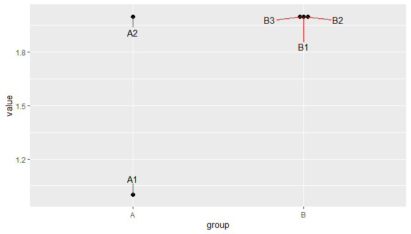

```r
df <- data.frame(name = c("A1","A2","B1","B2","B3"),
                 value = c(1,2,2,2,2),
                 group = c("A","A","B","B","B"))

ggplot(df, aes(x = group,y = value,label = name)) +
  geom_dotplot(binaxis = 'y', stackdir = 'center', dotsize = 0.7) +
  geom_text_repel(aes(segment.color = "red"),
                  box.padding = 1, max.overlaps = 10)
```

A1: As `geom_dotplot()` does not have a `stat` formal parameter and modifies the data it is impossible to access the positions of the points! As `group` is a factor a hypothetical `stat_dotplot()` would not work either, one would need to define a new geom `geom_labelled_dotoplot` to do the labelling in the same layer.

A2: `geom_point()` could be used together with a newly defined position function. This new function, possibly named `position_dotplot()`, would displace the observations’ coordinates using the same methods as `geom_dotplot()` uses to stack the dots. This function does not yet exist, but would allow a simple solution within the grammar of graphics.

## Repel from `geom_segment()` *issue #207 raised by ekatko1*

Q: Currently, the repel works to repel text away from single points. However, it would be great if it could repel text away from segments as well. This would be especially useful for automatically generating nice biplots for multivariate analysis (PCA, RDA, etc.).

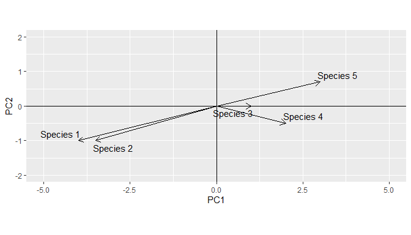

```r
## Example data frame where each species' principal components have been computed.
df = data.frame(
  Species = paste("Species",1:5),
  PC1     = c(-4, -3.5, 1, 2, 3),
  PC2     = c(-1, -1, 0, -0.5, 0.7))

## We plot the two primary principal componenets and add species labels
ggplot(df, aes(x=PC1, y = PC2, label=Species)) +
  geom_segment(aes(x=0, y=0, xend=PC1, yend=PC2),
               arrow = arrow(length = unit(0.1, "inches"))) +
  geom_text_repel() +
  xlim(-5, 5) +
  ylim(-2, 2) +
  # Stadard settings for displaying biplots
  geom_hline(aes(yintercept = 0), size=.2) +
  geom_vline(aes(xintercept = 0), size=.2) +
  coord_fixed()
```

A: Repulsion from segments is probably not the best approach, or at least useful only in sparse data cases. In the case of biplots a good approach is to use nudging away from the origin. Package ‘ggpp’ provides position functions implementing computed nudging that can be different for each individual observation. Nudging moves the initial position from which labels are repulsed, making their use together with repulsion usually effective.

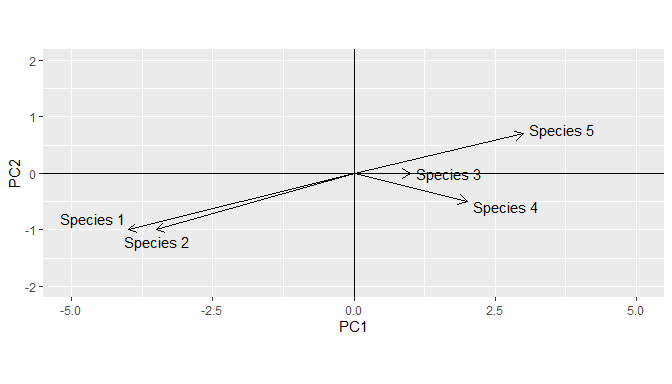

```r
## We nudge the starting coordinates of the labels away from the origin
ggplot(df, aes(x=PC1, y = PC2, label=Species)) +
  geom_segment(aes(x=0, y=0, xend=PC1, yend=PC2),
               arrow = arrow(length = unit(0.1, "inches"))) +
  geom_text_repel(position = position_nudge_centre(x = 0.2, y = 0.01,
                                                   center_x = 0, center_y = 0)) +
  xlim(-5, 5) +
  ylim(-2, 2) +
  # Stadard settings for displaying biplots
  geom_hline(aes(yintercept = 0), size=.2) +
  geom_vline(aes(xintercept = 0), size=.2) +
  coord_fixed()
```

In a more crowed plot we may want to allow overlaps but improve the visibility of the text with a semitransparent fill using `geom_label_repel()`.

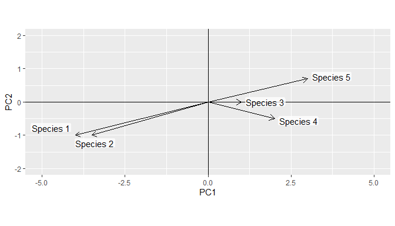

```r
## We nudge the labels manually
ggplot(df, aes(x=PC1, y = PC2, label=Species)) +
  geom_hline(aes(yintercept = 0), size=.2) +
  geom_vline(aes(xintercept = 0), size=.2) +
  geom_segment(aes(x=0, y=0, xend=PC1, yend=PC2),
               arrow = arrow(length = unit(0.1, "inches"))) +
  geom_label_repel(position = position_nudge_center(x = 0.2, y = 0.01,
                                                    center_x = 0, center_y = 0),
                   label.size = NA,
                   label.padding = 0.1,
                   fill = rgb(red = 1, green = 1, blue = 1, alpha = 0.75)) +
  xlim(-5, 5) +
  ylim(-2, 2) +
  # Stadard settings for displaying biplots
  coord_fixed()
```

In a plot of sparse data we may try to dispense with repulsion and rely purely on nudging using `geom_label_s()` from package ‘ggpp’. For the current example this results in overlapping data labels.

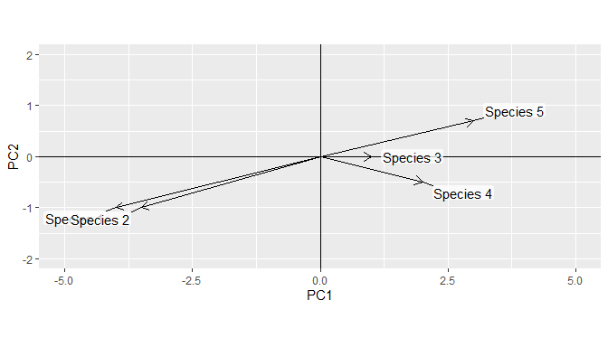

```r
## We nudge the labels manually
ggplot(df, aes(x=PC1, y = PC2, label=Species)) +
  geom_hline(aes(yintercept = 0), size=.2) +
  geom_vline(aes(xintercept = 0), size=.2) +
  geom_segment(aes(x=0, y=0, xend=PC1, yend=PC2),
               arrow = arrow(length = unit(0.1, "inches"))) +
  geom_label_s(position = position_nudge_center(x = 0.2, y = 0.3,
                                                center_x = 0, center_y = 0),
               linewidth = 0,
               label.padding = unit(0.1, "lines"),
               fill = rgb(red = 1, green = 1, blue = 1, alpha = 0.75)) +
  xlim(-5, 5) +
  ylim(-2, 2) +
  # Stadard settings for displaying biplots
  coord_fixed()
```

## Point `scale_size_area()` *issue #205 raised by sangwon-hyun*

Q: When using `scale_size_area()`, `point.size` needs to be adjusted, probably by a square root. It seems this should be the default behavior without the user specifying it.

A1: Rather than automating this, adding a `parameter` called `point.size.area` seems an approach consistent with ‘ggplot2’ and very easy to implement. Meanwhile, an equivalent manual approach is as follows.

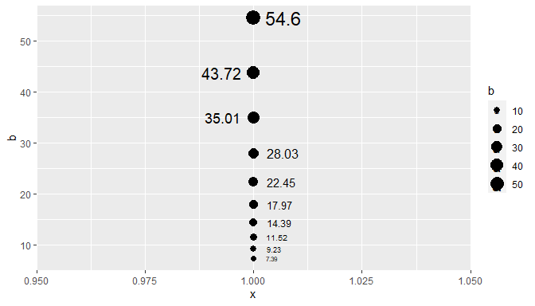

```r
size_from_area <- function(x) {sqrt(max(0, x) / pi)}

df <- data.frame(b = exp(seq(2, 4, length.out = 10)))
ggplot(df, aes(1, b, size = b)) +
  geom_point() +
  scale_size_area() +
  geom_text_repel(aes(label = round(b,2),
                      point.size = size_from_area(b) * 2),
                  box.padding = 0,
                  min.segment.length = 0,
                  direction = "x")
```

A2: In this case we can dispense with repulsion.

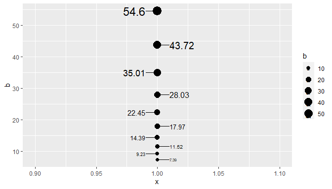

```r
size_from_area <- function(x) {sqrt(max(0, x) / pi)}

df <- data.frame(b = exp(seq(2, 4, length.out = 10)))
ggplot(df, aes(1, b, size = b)) +
  geom_point() +
  scale_size_area() +
  geom_text_s(aes(label = round(b,2),
                  point.padding = size_from_area(b) / 15),
              position = position_nudge_to(x = c(1.01, 0.99)),
              label.padding = 0,
              box.pading = 0) +
  xlim(0.9, 1.1)
```

## Allow sorting of labels *issue #201 raised by z3tt*

Q: Related to issue #200 that I filed today. It would be neat to order the boxes in decreasing or ascending order from left to right, bottom to top. I.e. now the order depends on the seed but would it be possible to have a logical order?

A: Nudging can help. In this case applying nudging by specifying the nudged *y* position for each label. Here we add increasing amounts of nudging. It would be better to start afresh by groups of labels. We need to sort the row in the data according to the position along the *x* axis for this approach to work.

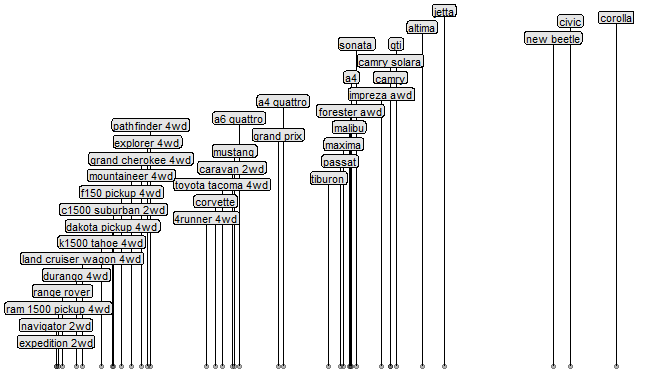

```r
set.seed(42)

mpg %>%
  group_by(model) %>%
  summarize(cty = mean(cty, na.rm = TRUE)) %>%
  arrange(cty) %>%
  ggplot(aes(x = cty, y = 1,
             label = model)) +
  geom_point(alpha = .3) +
  geom_label_repel(
    position = position_nudge_to(y = 2 + (1:length(unique(mpg$model)))/ 10),
    fill = "grey90",
    direction    = "y",
    max.iter = 1e4, max.time = 1,
    size = 3, ## tiny for reprex
    lineheight = .9,
    box.padding = 0.1,
    label.padding = 0.1
  ) +
  ylim(1, NA) +
  scale_x_continuous(expand = expansion(mult = c(0.1, 0.1))) +
  theme_void()
```

## Left-align text but not label boxes *issue #200 raised by z3tt*

Q: When forcing geom_text|label_repel() to draw vertical lines, one needs to use hjust = 0.5. Unfortunately, this argument applies justification to both the text and the textbox.

A: There is currently no solution available within ‘ggrepel’.

[figure not shown]

```r
set.seed(42)

## with left-aligned text (and thus no straight lines)
mpg %>%
  group_by(manufacturer, model) %>%
  summarize(cty = mean(cty, na.rm = TRUE)) -> mpg.summaries

ggplot(mpg.summaries,
       aes(x = cty, y = 1,
             label = paste0(manufacturer, "\n", model))) +
  geom_point(alpha = .3) +
  geom_label_repel(
    fill = "grey90",
    nudge_y      = .03,
    direction    = "y",
    hjust        = 0,
    max.iter = 1e4, max.time = 1,
    size = 1, ## tiny for reprex
    lineheight = .9
  ) +
  xlim(5, 30) +
  ylim(1, 0.95) +
  theme_void()
```

A: This would require separate parameters or a vector argument to set separately the justification for the text and for the anchor point of the segment. Should be easy to implement in `geom_label_s()` if needed.

## Line labels to the right of plot without overlapping *issue #185 raised by ericpgreen*

A: The original issue included a much more complex solution to this problem involving in addition formatting unrelated to ‘ggrepel’. The simplification is achieved by using nudging.

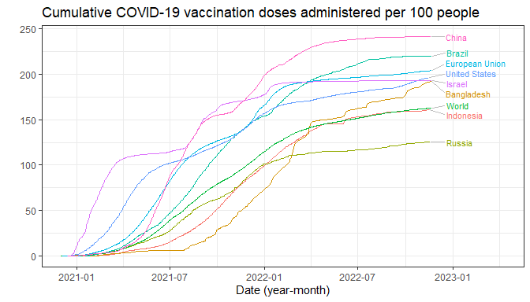

```r
keep <- c("Israel", "United States", "European Union", "China",
          "Russia", "Brazil", "World", "Indonesia", "Bangladesh")

data <- readr::read_csv("https://raw.githubusercontent.com/owid/covid-19-data/master/public/data/vaccinations/vaccinations.csv", lazy = FALSE, show_col_types = FALSE)

data %>%
  filter(location %in% keep) %>%
  select(location, date, total_vaccinations_per_hundred) %>%
  arrange(location, date) %>%
  filter(!is.na(total_vaccinations_per_hundred)) %>%
  mutate(location = factor(location),
         location = reorder(location, total_vaccinations_per_hundred)) %>%
  group_by(location) %>% # max(date) depends on the location!
  mutate(label = if_else(date == max(date),
                         as.character(location),
                         "")) -> owid

ggplot(owid,
       aes(x = date,
           y = total_vaccinations_per_hundred,
           color = location)) +
  geom_line() +
  geom_text_repel(aes(label = label),
                  size = 3,
                  position = position_nudge_to(x = max(owid$date) + days(30)),
                  segment.color = 'grey',
                  point.size = 0,
                  box.padding = 0.1,
                  point.padding = 0.1,
                  hjust = "left",
                  direction="y") +
  scale_x_date(expand = expansion(mult = c(0.05, 0.2))) +
  labs(title = "Cumulative COVID-19 vaccination doses administered per 100 people",
       y = "",
       x = "Date (year-month)") +
  theme_bw() +
  theme(legend.position = "none")
```

## Allow to both position_stack and position_nudge *issue #161 raised by krassowski*

Q: I was trying to achieve something similar as in this question: Is there a possibility to combine position_stack and nudge_x in a stacked bar chart in ggplot2?, but with ggrepel. I think I succeeded.

Having the following plot, I would like to move the names out of the bars and point to them with arrows.

A: `position_stacknudge()` from package ‘ggpp’ solves this.

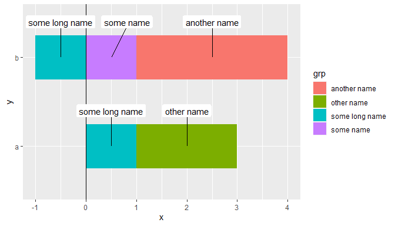

```r
df <- tibble::tribble(
  ~y, ~x, ~grp,
  "a", 1,  "some long name",
  "a", 2,  "other name",
  "b", 1,  "some name",
  "b", 3,  "another name",
  "b", -1, "some long name"
)

ggplot(data = df, aes(x, y, group = grp)) +
  geom_col(aes(fill = grp), width=0.5) +
  geom_vline(xintercept = 0) +
  geom_label_repel(aes(label = grp),
                   position = position_stacknudge(vjust = 0.5, y = 0.4),
                   label.size = NA)
```